# Project 1

```r
global_predictor <- c(
  "global_temp_anom_mean"
)

global_cor_tests <- bind_rows(
  lapply(
    global_predictor,
    function(x)
      correlation_by_region(
        region_year,
        x
      )
  )
)

global_cor_tests
```

| region | predictor | pearson_r | pearson_p | spearman_rho | spearman_p |
| --- | --- | --- | --- | --- | --- |
| Australasia | global_temp_anom_mean | 0.4959784 | 0.001797515 | 0.5033705 | 0.001494358 |
| Indian Ocean / Middle East | global_temp_anom_mean | 0.4885347 | 0.002156104 | 0.4384274 | 0.006642540 |
| Pacific | global_temp_anom_mean | 0.5114080 | 0.001216684 | 0.4653337 | 0.003706305 |
| West Atlantic | global_temp_anom_mean | 0.1747109 | 0.301028213 | 0.2045800 | 0.224520013 |

Apologies for all the numbers, but there are a few takeaways from this. 1. global_temp_anom_mean showed a satistically signficant positive correlation with the bleaching data for all regions (except for West Atlantic - the paper noticed something off about this region too) 2. nino 3.4 anomaly mean data (what we initally wanted to pursue) had varied corerlations with only the Pacific having a positive corelation with a significant p-value (so we can reject the null hypothesis that there is no corrrelation). what this might tell us is that there is a region-specific relationship with the nino data as the pacific region is very close to where the nino 3.4 data is actually measured

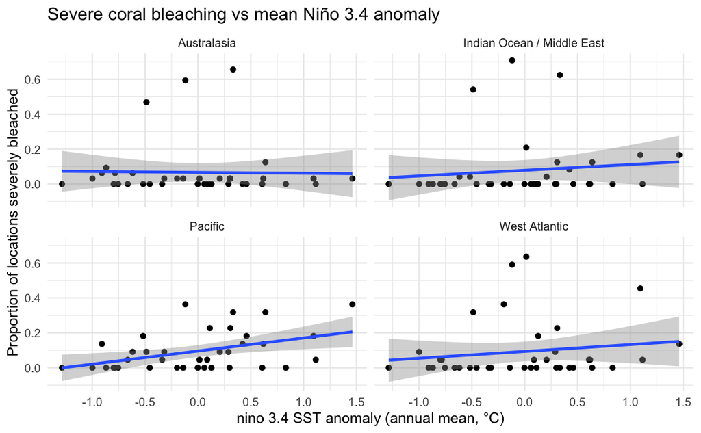

```r
#plotting it all out now
plot_bleaching_vs_predictor(
  region_year,
  "nino34_anom_mean",
  "nino 3.4 SST anomaly (annual mean, °C)",
  "Severe coral bleaching vs mean Niño 3.4 anomaly"
)
```

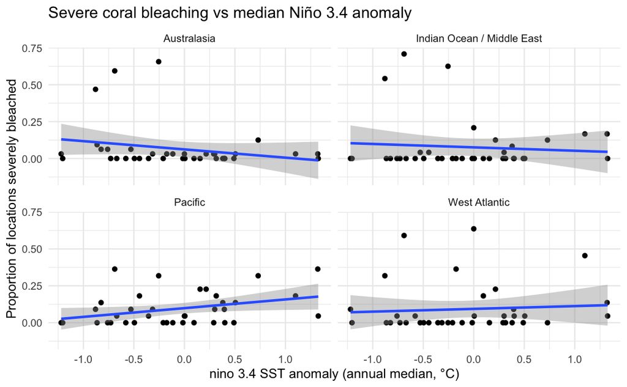

```r
plot_bleaching_vs_predictor(
  region_year,
  "nino34_anom_median",
  "nino 3.4 SST anomaly (annual median, °C)",
  "Severe coral bleaching vs median Niño 3.4 anomaly"
)
```

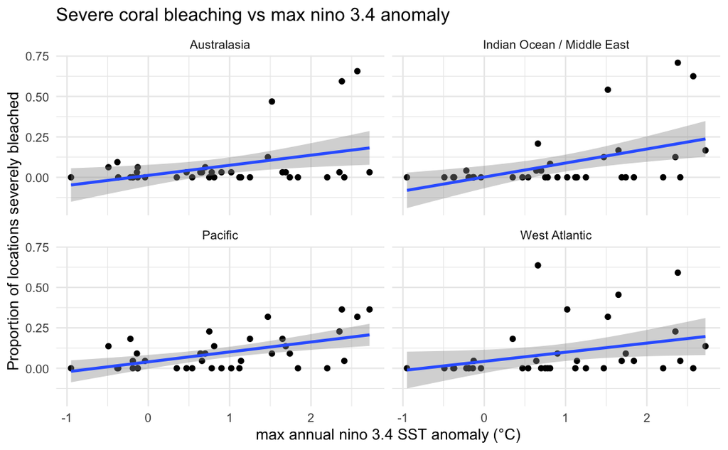

```r
plot_bleaching_vs_predictor(
  region_year,
  "nino34_anom_max",
  "max annual nino 3.4 SST anomaly (°C)",
  "Severe coral bleaching vs max nino 3.4 anomaly"
)
```

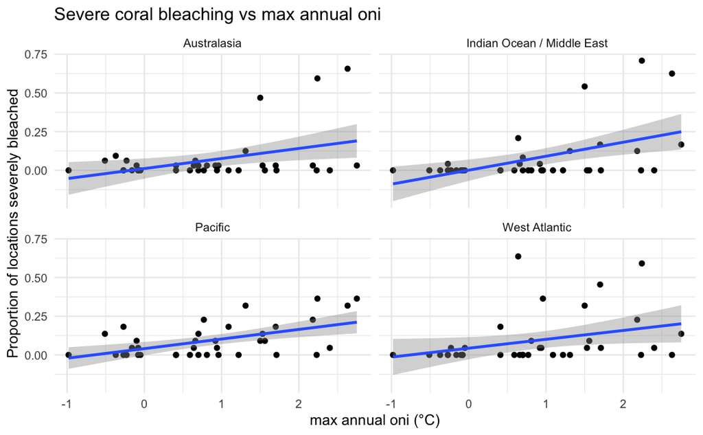

```r
plot_bleaching_vs_predictor(
  region_year,
  "oni_max",
  "max annual oni (°C)",
  "Severe coral bleaching vs max annual oni"
)
```

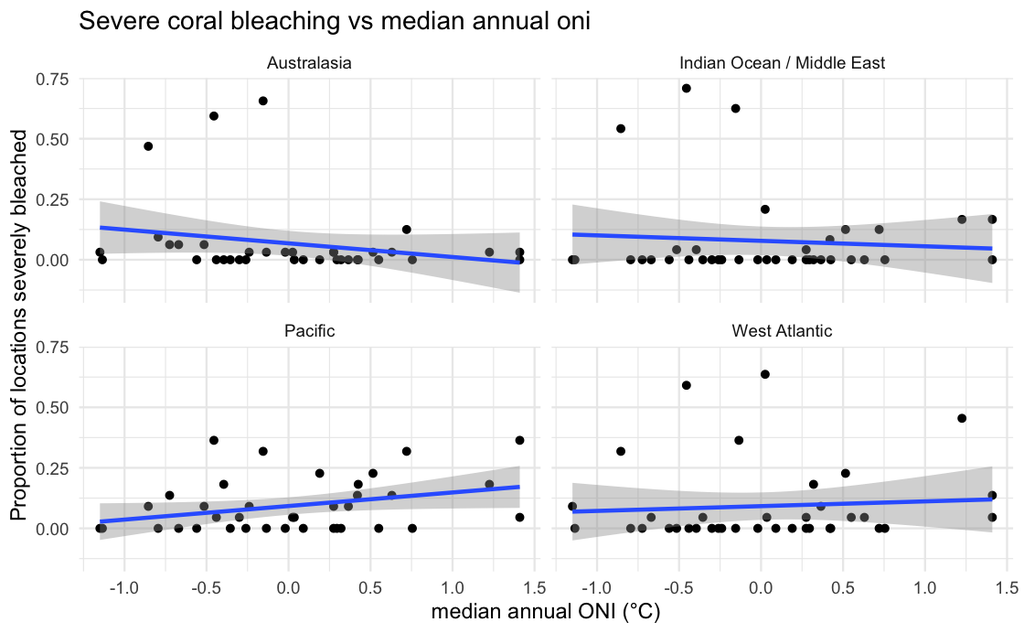

```r
plot_bleaching_vs_predictor(
  region_year,
  "oni_median",
  "median annual ONI (°C)",
  "Severe coral bleaching vs median annual oni"
)
```

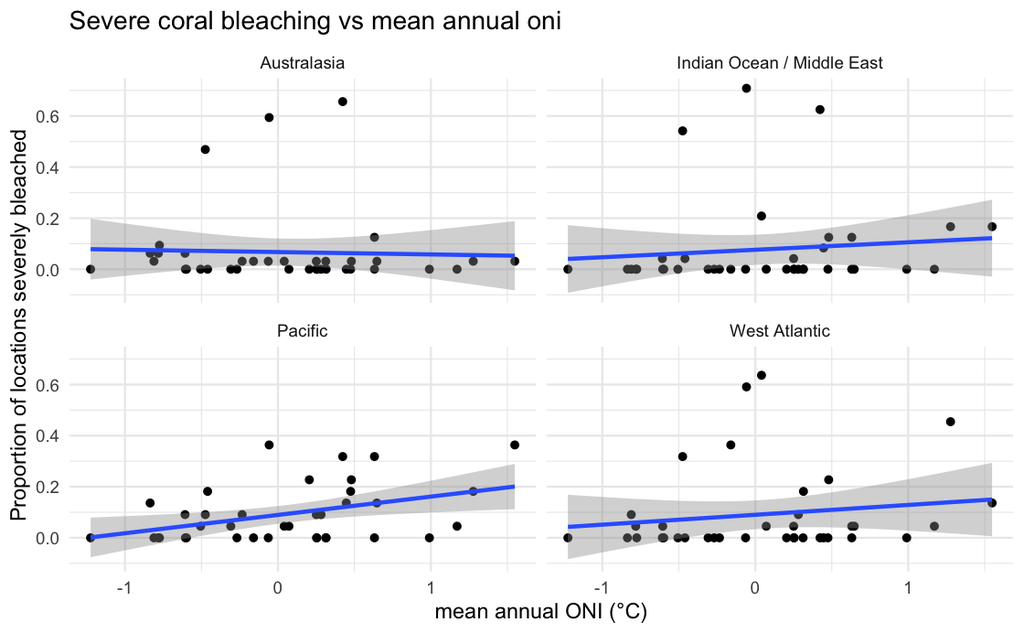

```r
plot_bleaching_vs_predictor(
  region_year,
  "oni_mean",
  "mean annual ONI (°C)",
  "Severe coral bleaching vs mean annual oni"
)
```

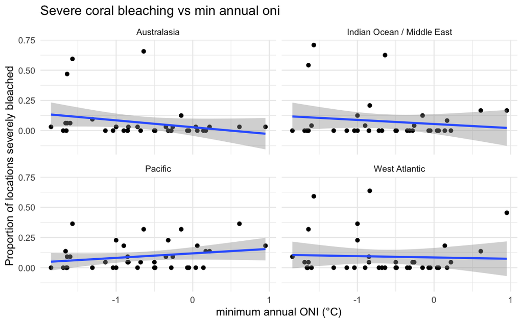

```r
plot_bleaching_vs_predictor(
  region_year,
  "oni_min",
  "minimum annual ONI (°C)",
  "Severe coral bleaching vs min annual oni"
)
```

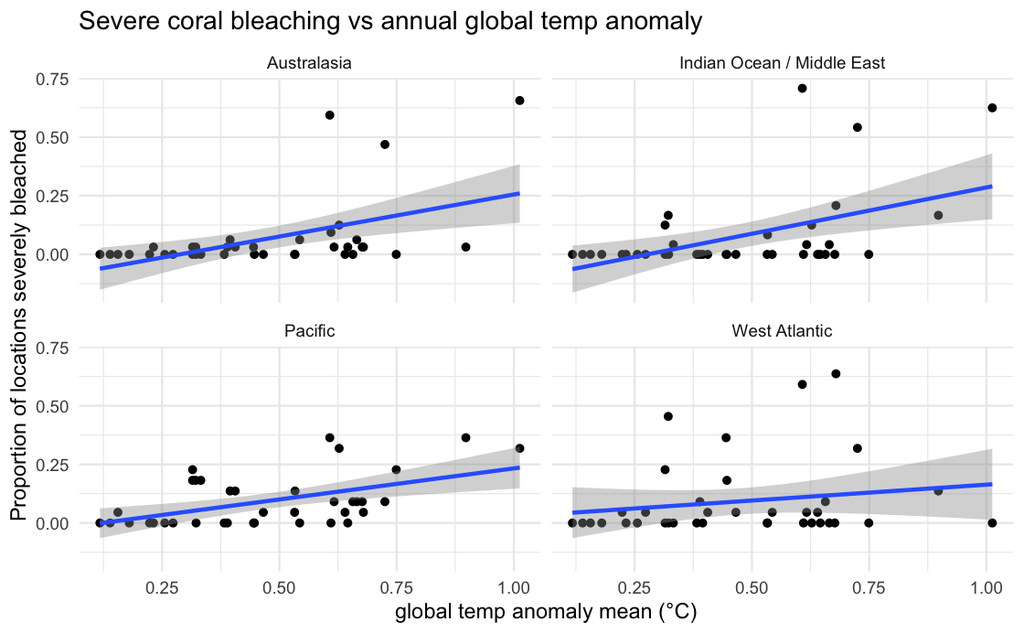

```r
plot_bleaching_vs_predictor(
  region_year,
  "global_temp_anom_mean",
  "global temp anomaly mean (°C)",
  "Severe coral bleaching vs annual global temp anomaly"
)
```

so that was visual representation essentially. the numbers show us the same thing. probably could have put whether it was signficant or not in the plot but it’s easier if i tell u that global anomaly had signficant results (expect for the west atlantic region - researcher’s also noticed this one was weird) and nino 3.4 was signficant for pscific but nothing else.

```r
#now we wanted to follow the type of model the paper did - a GLMM
#in r we can call on the glmer function to calculate the model for us just by inputting variables
#so now we esentially want to decide what fixed effects we want to use that differ from the paper's

#this is the quesiton we want to answer with the GLMM: How does the probability of severe bleaching change with -----------, allowing that relationship to differ by region, while also allowing each reef location to have its own persistent baseline tendency to bleach?

#we first add two new columns to our master_blenso table
#you might be wondering why we're basically calculating anomaly data again. we're centering it because we're only looking at a particular moment of time and so we center the data again
#we also do this because in our model, if we ever have one of the fixed effects as 0, we can have a much easier time calcylating the regional intercept
#so a GLMM involving this data is something like this:
# logit(p) = regional_intercept + region*something + random_effect
# or with more fixed effects (which we will try)
# logit(p) = regional_intercept + region*something + region*something_else + random_effect
#so if we ever have 0 for those somethings, we know it is the avg and we can find regional_intercept easily

master_blenso <- master_blenso %>%
  mutate(
    temp_c =
      global_temp_anom_mean -
      mean(global_temp_anom_mean, na.rm = TRUE),

    nino_c =
      nino34_anom_mean -
      mean(nino34_anom_mean, na.rm = TRUE)
  )

#ok glmer time now
#we are looking at three models
# 1. the researchers who use region and time (years since 1980) as fixed effects
# 2. ours - fixed effects being region and global anomaly temp
# 3. ours - fixed effects being region and global anomaly temp AND nino 3.4 anomaly temp

model_1_paper_time <- glmer(
  severe ~ #our model estimates P(severe = 1)
    0 + region + #we don't have an overall intercept because we want it to find one that is region-specific - this is part of fixed effects btw
    region:t + #this was the researchers' fixed effects (region and time (tyears since 1980))
    (1 | location_id), #random effect (more right below)
  data = master_blenso, #our dataset
  family = binomial, #glmer now knows our variable is binary
  control = glmerControl(
    optimizer = "bobyqa", #we ran into some troubles with the basic glmer function so we had to mess around a little (also more below)
    optCtrl = list(maxfun = 200000) #gives more opportunities for convergence
  )
)

#about the random effect because it was getting crowded - we look at one specific location (100 total) over many years so the observations at that sole location are not going to be independent. so this is trying to account for that location-specific variance
#1 sets a random intercept allowing for eahc location to have a specific intercept. what this essentially allows for is to say that each lcoation may have a bit of a higher or lower tendnecy to bleach severely from the baseline

#convergence and optimization
#converge is essentially when as good of parameter combination has been found (a sweet spot where tiny differences don't make big changes anymore)
#an optimizer has to consider a lot of stuff and the default one wasn't doing too great. the researcher's also had to tweak some stuff.
#shoutout https://stackoverflow.com/questions/33670628/solution-to-the-warning-message-using-glmer for not being the only person with this problem
#the specification of the optimizer doesn't change the model, only the method used to estimate the paprameters
#this was a bit out of my depth but the following stack overflow advice worked - https://www.damtp.cam.ac.uk/user/na/NA_papers/NA2009_06.pdf

model_2_global <- glmer(
  severe ~ #our model estimates P(severe = 1)
    0 + region + #we don't have an overall intercept because we want it to find one that is region-specific - this is part of fixed effects btw
    region:temp_c + #this is our region and global anomaly fixed effects
    (1 | location_id), #
  data = master_blenso,
  family = binomial,
  control = glmerControl(
    optimizer = "bobyqa", #we ran into some troubles with the basic glmer function so we had to mess aorund a little
    optCtrl = list(maxfun = 200000)
  )
)

model_3_global_and_nino <- glmer(
  severe ~
    0 + region +
    region:temp_c +
    region:nino_c +
    (1 | location_id), # this is our random effect btdubs
  data = master_blenso,
  family = binomial,
  control = glmerControl(
    optimizer = "bobyqa", #we ran into some troubles with the basic glmer function so we had to mess aorund a little
    optCtrl = list(maxfun = 200000)
  )
)

summary(model_1_paper_time)
```

```
Generalized linear mixed model fit by maximum likelihood (Laplace Approximation) ['glmerMod']
 Family: binomial  ( logit )
Formula: severe ~ 0 + region + region:t + (1 | location_id)
   Data: master_blenso
Control: glmerControl(optimizer = "bobyqa", optCtrl = list(maxfun = 200000))

      AIC       BIC    logLik -2*log(L)  df.resid
   1984.8    2040.8    -983.4    1966.8      3691

Scaled residuals:
    Min      1Q  Median      3Q     Max
-0.5099 -0.3288 -0.2841 -0.1751  8.9023

Random effects:
 Groups      Name        Variance Std.Dev.
 location_id (Intercept) 0.03742  0.1934
Number of obs: 3700, groups:  location_id, 100

Fixed effects:
                                     Estimate Std. Error z value             Pr(>|z|)
regionAustralasia                  -4.7034713  0.3792410 -12.402 < 0.0000000000000002 ***
regionIndian Ocean / Middle East   -4.0422950  0.3605079 -11.213 < 0.0000000000000002 ***
regionPacific                      -3.1861919  0.2948316 -10.807 < 0.0000000000000002 ***
regionWest Atlantic                -2.2890136  0.2417664  -9.468 < 0.0000000000000002 ***
regionAustralasia:t                 0.0922876  0.0138178   6.679      0.0000000000241 ***
regionIndian Ocean / Middle East:t  0.0728153  0.0136956   5.317      0.0000001056691 ***
regionPacific:t                     0.0448057  0.0120004   3.734             0.000189 ***
regionWest Atlantic:t              -0.0007754  0.0113612  -0.068             0.945584
---
Signif. codes:  0 ‘***’ 0.001 ‘**’ 0.01 ‘*’ 0.05 ‘.’ 0.1 ‘ ’ 1

Correlation of Fixed Effects:
            rgnAst rgIO/ME rgnPcf rgnWsA rgnAs: rIO/ME: rgnPc:
rgnIndnO/ME  0.007
regionPacfc  0.008  0.008
rgnWstAtlnt  0.008  0.008   0.009
rgnAstrls:t -0.943 -0.002  -0.002 -0.002
rgnIO/MEst: -0.002 -0.926  -0.002 -0.002  0.001
reginPcfc:t -0.002 -0.002  -0.896 -0.002  0.000  0.000
rgnWAtlntc:  0.000  0.000   0.000 -0.842  0.000  0.000   0.000
```

```r
summary(model_2_global)
```

```
Generalized linear mixed model fit by maximum likelihood (Laplace Approximation) ['glmerMod']
 Family: binomial  ( logit )
Formula: severe ~ 0 + region + region:temp_c + (1 | location_id)
   Data: master_blenso
Control: glmerControl(optimizer = "bobyqa", optCtrl = list(maxfun = 200000))

      AIC       BIC    logLik -2*log(L)  df.resid
   1850.5    1906.4    -916.3    1832.5      3691

Scaled residuals:
    Min      1Q  Median      3Q     Max
-1.0806 -0.3310 -0.2430 -0.1291 10.7258

Random effects:
 Groups      Name        Variance Std.Dev.
 location_id (Intercept) 0.06424  0.2535
Number of obs: 3700, groups:  location_id, 100

Fixed effects:
                                        Estimate Std. Error z value             Pr(>|z|)
regionAustralasia                        -3.3584     0.1907 -17.614 < 0.0000000000000002 ***
regionIndian Ocean / Middle East         -3.1189     0.1988 -15.691 < 0.0000000000000002 ***
regionPacific                            -2.4759     0.1517 -16.326 < 0.0000000000000002 ***
regionWest Atlantic                      -2.3602     0.1398 -16.882 < 0.0000000000000002 ***
regionAustralasia:temp_c                  6.0966     0.6465   9.430 < 0.0000000000000002 ***
regionIndian Ocean / Middle East:temp_c   5.8527     0.6968   8.400 < 0.0000000000000002 ***
regionPacific:temp_c                      3.0942     0.5747   5.384         0.0000000728 ***
regionWest Atlantic:temp_c                1.5839     0.5577   2.840              0.00451 **
---
Signif. codes:  0 ‘***’ 0.001 ‘**’ 0.01 ‘*’ 0.05 ‘.’ 0.1 ‘ ’ 1

Correlation of Fixed Effects:
            rgnAst rgIO/ME rgnPcf rgnWsA rgnA:_ rIO/ME: rgnP:_
rgnIndnO/ME  0.022
regionPacfc  0.028  0.026
rgnWstAtlnt  0.027  0.026   0.032
rgnAstrls:_ -0.706 -0.009  -0.012 -0.011
rgnIO/MEs:_ -0.009 -0.676  -0.011 -0.011  0.004
rgnPcfc:tm_ -0.006 -0.005  -0.426 -0.007  0.002  0.002
rgnWAtlnt:_ -0.002 -0.002  -0.003 -0.238  0.001  0.001   0.001
```

```r
summary(model_3_global_and_nino)
```

```
Generalized linear mixed model fit by maximum likelihood (Laplace Approximation) ['glmerMod']
 Family: binomial  ( logit )
Formula: severe ~ 0 + region + region:temp_c + region:nino_c + (1 | location_id)
   Data: master_blenso
Control: glmerControl(optimizer = "bobyqa", optCtrl = list(maxfun = 200000))

      AIC       BIC    logLik -2*log(L)  df.resid
   1822.1    1902.9    -898.0    1796.1      3687

Scaled residuals:
    Min      1Q  Median      3Q     Max
-1.0994 -0.3261 -0.2360 -0.1160 18.0725

Random effects:
 Groups      Name        Variance Std.Dev.
 location_id (Intercept) 0.07173  0.2678
Number of obs: 3700, groups:  location_id, 100

Fixed effects:
                                        Estimate Std. Error z value             Pr(>|z|)
regionAustralasia                       -3.67114    0.23228 -15.805 < 0.0000000000000002 ***
regionIndian Ocean / Middle East        -3.13325    0.20358 -15.391 < 0.0000000000000002 ***
regionPacific                           -2.54503    0.15757 -16.151 < 0.0000000000000002 ***
regionWest Atlantic                     -2.38476    0.14299 -16.678 < 0.0000000000000002 ***
regionAustralasia:temp_c                 7.77966    0.85284   9.122 < 0.0000000000000002 ***
regionIndian Ocean / Middle East:temp_c  5.96501    0.77061   7.741  0.00000000000000989 ***
regionPacific:temp_c                     2.58821    0.56319   4.596  0.00000431457766247 ***
regionWest Atlantic:temp_c               1.35611    0.55419   2.447             0.014404 *
regionAustralasia:nino_c                -1.00512    0.25162  -3.995  0.00006478751940463 ***
regionIndian Ocean / Middle East:nino_c -0.07917    0.22994  -0.344             0.730618
regionPacific:nino_c                     0.74308    0.20079   3.701             0.000215 ***
regionWest Atlantic:nino_c               0.39109    0.19284   2.028             0.042559 *
---
Signif. codes:  0 ‘***’ 0.001 ‘**’ 0.01 ‘*’ 0.05 ‘.’ 0.1 ‘ ’ 1

Correlation of Fixed Effects:
              rgnAst rgIO/ME rgnPcf rgnWsA rgnAstrls:t_ rgnIO/MEst:t_ rgnPcfc:t_ rgnWAtlntc:t_ rgnAstrls:n_ rgnIO/MEst:n_
rgnIndnO/ME    0.020
regionPacfc    0.026  0.027
rgnWstAtlnt    0.025  0.025   0.032
rgnAstrls:t_  -0.804 -0.009  -0.012 -0.011
rgnIO/MEst:t_ -0.008 -0.679  -0.010 -0.010  0.004
rgnPcfc:tm_   -0.006 -0.006  -0.315 -0.007  0.003        0.002
rgnWAtlntc:t_ -0.002 -0.002  -0.003 -0.188  0.001        0.001         0.001
rgnAstrls:n_   0.499  0.003   0.004  0.004 -0.555       -0.001        -0.001      0.000
rgnIO/MEst:n_ -0.001  0.173  -0.001 -0.001  0.000       -0.412         0.000      0.000         0.000
rgnPcfc:nn_   -0.005 -0.005  -0.270 -0.006  0.002        0.002        -0.182      0.000        -0.001        0.000
rgnWAtlntc:n_ -0.002 -0.002  -0.002 -0.163  0.001        0.001         0.000     -0.185         0.000        0.000
              rgnPcfc:n_
rgnIndnO/ME
regionPacfc
rgnWstAtlnt
rgnAstrls:t_
rgnIO/MEst:t_
rgnPcfc:tm_
rgnWAtlntc:t_
rgnAstrls:n_
rgnIO/MEst:n_
rgnPcfc:nn_
rgnWAtlntc:n_  0.000
```

```r
#what were our fixed effects
fixef(model_1_paper_time)
```

```
                 regionAustralasia   regionIndian Ocean / Middle East                      regionPacific
                      -4.703471328                       -4.042294959                       -3.186191891
               regionWest Atlantic                regionAustralasia:t regionIndian Ocean / Middle East:t
                      -2.289013590                        0.092287568                        0.072815334
                   regionPacific:t              regionWest Atlantic:t
                       0.044805724                       -0.000775433
```

```r
fixef(model_2_global)
```

```
                      regionAustralasia        regionIndian Ocean / Middle East                           regionPacific
                              -3.358425                               -3.118880                               -2.475923
                    regionWest Atlantic                regionAustralasia:temp_c regionIndian Ocean / Middle East:temp_c
                              -2.360202                                6.096599                                5.852710
                   regionPacific:temp_c              regionWest Atlantic:temp_c
                               3.094241                                1.583876
```

```r
fixef(model_3_global_and_nino)
```

```
                      regionAustralasia        regionIndian Ocean / Middle East                           regionPacific
                            -3.67114367                             -3.13325343                             -2.54502821
                    regionWest Atlantic                regionAustralasia:temp_c regionIndian Ocean / Middle East:temp_c
                            -2.38475570                              7.77965599                              5.96500964
                   regionPacific:temp_c              regionWest Atlantic:temp_c                regionAustralasia:nino_c
                             2.58821120                              1.35610894                             -1.00512242
regionIndian Ocean / Middle East:nino_c                    regionPacific:nino_c              regionWest Atlantic:nino_c
                            -0.07916968                              0.74307872                              0.39108915
```

```r
#random effect
isSingular(model_1_paper_time)
```

```
[1] FALSE
```

```r
isSingular(model_2_global)
```

```
[1] FALSE
```

```r
isSingular(model_3_global_and_nino)
```

```
[1] FALSE
```

```r
#reef to reef variation
VarCorr(model_1_paper_time)
```

```
 Groups      Name        Std.Dev.
 location_id (Intercept) 0.19343
```

```r
VarCorr(model_2_global)
```

```
 Groups      Name        Std.Dev.
 location_id (Intercept) 0.25346
```

```r
VarCorr(model_3_global_and_nino)
```

```
 Groups      Name        Std.Dev.
 location_id (Intercept) 0.26783
```

we have all positive global temperature slopes and they’re significant. joy! (look at estiamte columns for temp_c and **** stuff) - what is extra cool is that the paper’s model had a - slope and we have a very slight positive one it is cery cool to see how the slopes are actually different depending on the region! this is pretty cool im happy

so right now we can pretty safely say that the enso data helps and it shows the differences between regions but its still not the best predictor (like universal predictor) from looking at these values

```r
#which model works better? - prev outputs kinds showed this but this is cleaner
#we can use AIC and BIC
#i knew nothing about these so hopefully this makes sense

#im sure there are other ways to compare, but a lot of stuff primarly mentioned GLMs so i was worried we coudn't apply it

# basically, i feared overfitting - the models would be too focused on nino anomaly data (which already was weird during correlation) and would mess everything up. so AIC and BIC kind of penalize for complexity that could lead to this (from what i udnerstand)
# shoutout this source: https://medium.com/@jshaik2452/choosing-the-best-model-a-friendly-guide-to-aic-and-bic-af220b33255f
#BIC seems to be stricter

#this is also in the summary stuff above but it is easier to see here
AIC(
  model_1_paper_time,
  model_2_global,
  model_3_global_and_nino
)
```

|  | df | AIC |
| --- | --- | --- |
| model_1_paper_time | 9 | 1984.834 |
| model_2_global | 9 | 1850.501 |
| model_3_global_and_nino | 13 | 1822.099 |

```r
BIC(
  model_1_paper_time,
  model_2_global,
  model_3_global_and_nino
)
```

|  | df | BIC |
| --- | --- | --- |
| model_1_paper_time | 9 | 2040.779 |
| model_2_global | 9 | 1906.446 |
| model_3_global_and_nino | 13 | 1902.908 |

```r
#scores depends on a amthematical function so i don't think theres a real scale to use. we just want it to be lower than our other models
```

So now oddly enough, model 3 seems to work best (despite the nino anomaly data not always having signficant correlation with regional severe bleaching proportion). It is not drastically different, but we still get better results than the paper’s model for both oof ours (which is what we wanted). This essentially gives us a model to code in colab and simulate now.

```r
#so to actually make a very clear table that we will use in colab now
#btw if i wrote colabfold anywhere im so sorry it is the first thing i associate with colab notebook and i always miss when i write it or mention. it

master_location_year <- master %>%
  select(
    location_id,
    region,
    year,
    t,
    severe,
    global_temp_anom_mean,
    nino34_anom_mean,
    temp_c,
    nino_c
  )

# quick checks
glimpse(master_location_year)
```

```
Rows: 3,700
Columns: 9
$ location_id           <dbl> 1, 1, 1, 1, 1, 1, 1, 1, 1, 1, 1, 1, 1, 1, 1, 1, 1, 1, 1, 1, 1, 1, 1, 1, 1, 1, 1, 1, 1, 1, 1, 1, …
$ region                <chr> "Australasia", "Australasia", "Australasia", "Australasia", "Australasia", "Australasia", "Austr…
$ year                  <dbl> 1980, 1981, 1982, 1983, 1984, 1985, 1986, 1987, 1988, 1989, 1990, 1991, 1992, 1993, 1994, 1995, …
$ t                     <dbl> 0, 1, 2, 3, 4, 5, 6, 7, 8, 9, 10, 11, 12, 13, 14, 15, 16, 17, 18, 19, 20, 21, 22, 23, 24, 25, 26…
$ severe                <int> 0, 0, 0, 0, 0, 0, 0, 0, 0, 0, 0, 0, 0, 0, 0, 0, 0, 0, 1, 0, 0, 0, 1, 0, 0, 0, 0, 0, 0, 0, 0, 0, …
$ global_temp_anom_mean <dbl> 0.2558333, 0.3225000, 0.1391667, 0.3150000, 0.1558333, 0.1175000, 0.1800000, 0.3216667, 0.389166…
$ nino34_anom_mean      <dbl> -0.001666667, -0.455833333, 0.831666667, 0.306666667, -0.664166667, -0.755000000, 0.060000000, 1…
$ temp_c                <dbl> -0.217995495, -0.151328829, -0.334662162, -0.158828829, -0.317995495, -0.356328829, -0.293828829…
$ nino_c                <dbl> 0.03018018, -0.42398649, 0.86351351, 0.33851351, -0.63231982, -0.72315315, 0.09184685, 1.1260135…
```

```r
nrow(master_location_year)
```

```
[1] 3700
```

```r
n_distinct(master_location_year$location_id)
```

```
[1] 100
```

```r
n_distinct(master_location_year$year)
```

```
[1] 37
```

```r
# export for Colab
write_csv(
  master_location_year,
  "master_location_year.csv"
)
```

Here are some other sources used but not mentioned in the hashtags because it was getting messy - these are not necessarily professional or academic sources but credit where credit is due because they helped https://www.reddit.com/r/AskStatistics/comments/duth2j/use_of_aic_to_compare_models/ https://www.rdocumentation.org/packages/stats/versions/3.6.2/topics/AIC https://www.reddit.com/r/statistics/comments/11dlcvd/question_help_with_glmm_in_r/ https://www.rdocumentation.org/packages/mclust/versions/6.0.0/topics/bic https://medium.com/@jshaik2452/choosing-the-best-model-a-friendly-guide-to-aic-and-bic-af220b33255f